# IODS course project

Robert Leigh

# Chapter 1 - A beginning

*This is the first exercise for the Introduction to Open Data Science course. It includes a link to my github repository.*

https://github.com/robertscottleigh/IODS-project.git

This week’s work was focused on setting up tools necessary for completing the rest of the course, including the use of Github and Rstudio. Github includes a website and accompanying software and is used for version control. This may be done using a desktop or command-line version. As I will be completing this course on university computers on which I do not have administrator rights, I have opted to simply upload my files directly to Github. A project template was available for use in the course, including three R markdown files for modification. These were modified to include necessary info (name, links to github pages) and knitted to an html document for publication. As this is now my third course in which Rstudio was used, this went very smoothly. I look forward to getting into the data!

# Chapter 2 - Regression and model variation

Structure and dimensions of data. The dataset consists of results from a questionairre of students. It consists of 7 variables: gender, age, attitude, deep learning, strategic learning, surface learning, and points awwarded on an exam. Individuals (166 total) are in rows and variables measured are in columns. Note that for this report, descriptions of the data are just above the code/plots.

```r
learning2014 <- read.csv("C:/HY-Data/LEIGH/course material/introduction_to_open_data_science/IODS_project_6_nov/data/learning2014.csv")
str(learning2014)
```

```
## 'data.frame':    166 obs. of  7 variables:
##  $ gender  : Factor w/ 2 levels "F","M": 1 2 1 2 2 1 2 1 2 1 ...
##  $ age     : int  53 55 49 53 49 38 50 37 37 42 ...
##  $ attitude: num  3.7 3.1 2.5 3.5 3.7 3.8 3.5 2.9 3.8 2.1 ...
##  $ deep    : num  3.58 2.92 3.5 3.5 3.67 ...
##  $ stra    : num  3.38 2.75 3.62 3.12 3.62 ...
##  $ surf    : num  2.58 3.17 2.25 2.25 2.83 ...
##  $ points  : int  25 12 24 10 22 21 21 31 24 26 ...
```

```r
dim(learning2014)
```

```
## [1] 166   7
```

```r
library(GGally)
```

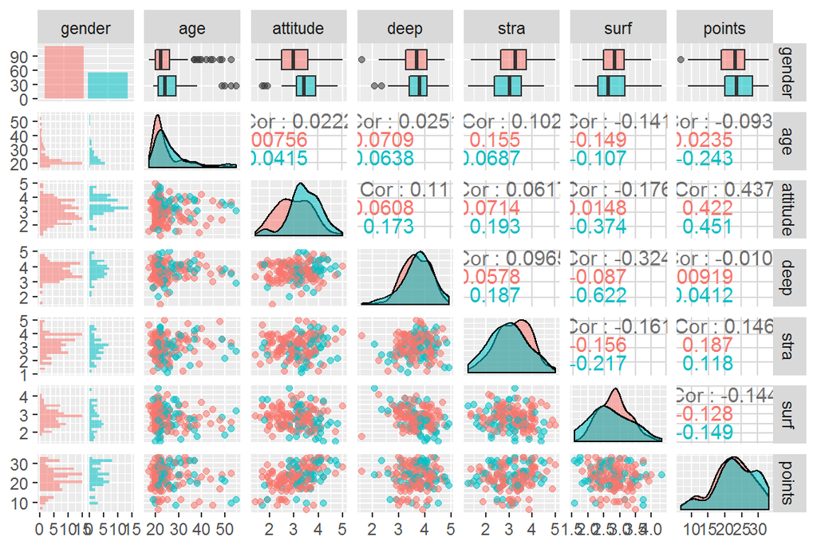

```r
library(ggplot2)
ggpairs(learning2014, mapping = aes(col = gender, alpha = 0.3), lower = list(combo = wrap("facethist", bins = 20)))
```

Summary of the variables in the data. The ‘summary’ function allows a text-based overview of a datset, presenting interquartile range, min/max, median, and mean of all numeric variables in a dataset, and numerical representations of categorical variables. This is a very good first step, especially if you are not very familiar with a dataset. In the learning 2014 dataset, the course participants were mostly female (110/166) and their age ranges were from 17-55. The median student age was 22 years old. Performance on the exam ranged from a low of 7 points to a high of 33 points, with an average score of 22.72. The results of survey questions, including the variables attitude, deep, stra, and surf were 1:5 scale.

```r
summary(learning2014)
```

```
##  gender       age           attitude          deep            stra
##  F:110   Min.   :17.00   Min.   :1.400   Min.   :1.583   Min.   :1.250
##  M: 56   1st Qu.:21.00   1st Qu.:2.600   1st Qu.:3.333   1st Qu.:2.625
##          Median :22.00   Median :3.200   Median :3.667   Median :3.188
##          Mean   :25.51   Mean   :3.143   Mean   :3.680   Mean   :3.121
##          3rd Qu.:27.00   3rd Qu.:3.700   3rd Qu.:4.083   3rd Qu.:3.625
##          Max.   :55.00   Max.   :5.000   Max.   :4.917   Max.   :5.000
##       surf           points
##  Min.   :1.583   Min.   : 7.00
##  1st Qu.:2.417   1st Qu.:19.00
##  Median :2.833   Median :23.00
##  Mean   :2.787   Mean   :22.72
##  3rd Qu.:3.167   3rd Qu.:27.75
##  Max.   :4.333   Max.   :33.00
```

Based on the graphical representations, attitude, stra, and surf were chosen as explanatory variables for points. The lm() function is used for generating a linear model, and summary() used to display results. This model shows only “attitude” is a statistically significant explanatory variable (p=1.93e-08). The variable “stra” is close to significance (p=0.11716), and the variable “surf” is not significant (0.46563). Only “attitude”" is included in further analysis.

```r
model_1 <- lm(points ~ attitude + stra + surf, data = learning2014)
summary(model_1)
```

```
##
## Call:
## lm(formula = points ~ attitude + stra + surf, data = learning2014)
##
## Residuals:
##      Min       1Q   Median       3Q      Max
## -17.1550  -3.4346   0.5156   3.6401  10.8952
##
## Coefficients:
##             Estimate Std. Error t value Pr(>|t|)
## (Intercept)  11.0171     3.6837   2.991  0.00322 **
## attitude      3.3952     0.5741   5.913 1.93e-08 ***
## stra          0.8531     0.5416   1.575  0.11716
## surf         -0.5861     0.8014  -0.731  0.46563
## ---
## Signif. codes:  0 '***' 0.001 '**' 0.01 '*' 0.05 '.' 0.1 ' ' 1
##
## Residual standard error: 5.296 on 162 degrees of freedom
## Multiple R-squared:  0.2074, Adjusted R-squared:  0.1927
## F-statistic: 14.13 on 3 and 162 DF,  p-value: 3.156e-08
```